# SpatialSchellingToronto

PC & CC

23 septembre 2018

## Library loading

We load a bunch of libraries

```r
library(sf)
```

```r
library(ggplot2)
library(dplyr)
library(RColorBrewer)
library(ineq)
library(cancensus)
library(cancensusHelpers)
```

## Getting Toronto

Toronto data is available as a `Rdata` object, at the root of the modeling directory, we load it. It’s a `sf` object, i.e. a dataframe , with a geometry special column for each row.

```r
load("cityTractsWithPopAndVacancy.RData")

mytoronto <-  na.omit(toronto_tr)
tractIDS <-  as.character(unique(mytoronto$GeoUID))
mytoronto$popSchelling <-  NA
```

Observe that two objects have spawned in your memory : “toronto_tr” and “vancouver_tr”. We will work on Toronto , so we got rid of NA values that can persist in the data object, we keep tracts IDs in a list and initialize a simulated population column.

### State Creation

State is no longer a square matrix, it will be the tracts of Toronto. First we check the aspect of the spatial object `mytoronto`,

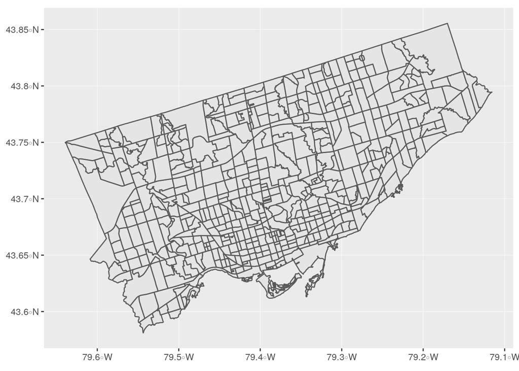

```r
ptor  <-  ggplot(mytoronto) +
  geom_sf()
ptor
```

```r
nbgroups <-  4
groupValues <-  seq.int(from = 1, to=nbgroups)
colorMapping <-  brewer.pal(nbgroups,"Dark2")
pctList <- c(0.6, 0.1, 0.1, 0.1)
pctList %>%  sum
```

```
## [1] 0.9
```

The state will be a dataframe where :

- each line is a householder
- the group of the householder is stored in the `value` column
- `localisation` column is the tract where the householder currently lives
- `ID` is (surprinsigly) an ID

Householders values are sampled accroding to the proportion list, and are spatialized in tracts according to ther relative population weights of the tracts.

```r
genSchellingTractState <-  function(popSize,  mytoronto, pctList, groupValues){
  #every ID of tortonto tracks
  tractIDS <-  unique(mytoronto$GeoUID)
  #toronto total population to get tract relative population weights
  popTotal <-  sum(mytoronto$Population)

  #value is sampled according to given proportoion
  value <- sample(groupValues, size = popSize,replace = T, prob = pctList)

  # localisation is sampled according to tracts populations weights
  localisation <-  as.character(sample(tractIDS, size= popSize , replace = T , prob= mytoronto$Population / popTotal ))
  ID <-  seq.int(popSize)
  happy <-  NA

  #creation of the dataframe
  res <- data.frame(ID,localisation,value, happy, stringsAsFactors = F)
return(res)
  }


s <-  genSchellingTractState(10000,mytoronto,pctList, groupValues)
#to see what it looks like
head(s, 10)
```

```
##    ID localisation value happy
## 1   1   5350378.25     1    NA
## 2   2   5350166.00     1    NA
## 3   3   5350207.00     1    NA
## 4   4   5350029.00     1    NA
## 5   5   5350376.09     4    NA
## 6   6   5350276.01     4    NA
## 7   7   5350313.00     1    NA
## 8   8   5350270.02     3    NA
## 9   9   5350121.00     2    NA
## 10 10   5350112.00     1    NA
```

### Happiness Update of One Householder

```r
isHappyInTract <-  function (ID, state, tolerance){
  hhLoc <-  state[ID,"localisation"]
  hhValue <-  state[ID, "value"]

  #neighbourhood
  neigh <-  state %>%  filter(localisation == hhLoc)

  numberOfDiff <-sum(hhValue!=neigh$value, na.rm = T)
  happy <-  (numberOfDiff / nrow(neigh) ) < tolerance
  return(happy)
}
```

#### Happiness update of the whole state

To update the whole state’s happiness we could apply the previous function on every line of the state dataframe.

```r
updateHappiness <- function(state, tolerance){
  state$happy <-  sapply(state$ID, FUN = isHappyInTract, state=state, tolerance = 0.3)
  return(state)
}
```

This has to be done at intialization but afterwards , during simulation , there is no need to update everybody’s happiness, as a lot of householders won’t be affeceted by the move of a householder from a tract to another. To speed up this update, we specialize a function to update the happiness of a single tract.

```r
updateHappinessOftract <- function(tract, state, tolerance){
    state[state$localisation == tract,]$happy <-  sapply(state[state$localisation == tract,]$ID, FUN = isHappyInTract, state=state, tolerance = 0.3)
  return(state)
}
```

Finally we make a “getter” function to return unhappyHouseholders.

```r
getUnhappy <-  function(state){
  return(filter(state, !happy))
}
```

## Dynamics

Dynamics are similar : we sample unhappy householders, and change its localisation to another one, taken at random (provided it has some spare room). For now we make the hypothesis that every tract can welcome the total population, vacancy will be taken into account here.

```r
moveOne <-  function(state, tolerance, tractIDS) {
  if (nrow(getUnhappy(state)) == 0) {
    cat("everyone happy \n")
    return(state)
  }

  unhappyHHs <-  getUnhappy(state)
  #take one unhappy householder
  uhhhID <- sample(unhappyHHs$ID, 1)
  #take one tract at random
  destiTract <-  sample(tractIDS, 1)
  origTract <-  state[uhhhID, "localisation"]

  #the localisation change
  state[uhhhID, "localisation"] <-  destiTract

  #only the two concerned tracts will see their happiness changed by the move of the householder
  state <-  updateHappinessOftract(origTract, state, tolerance)
  state <-  updateHappinessOftract(destiTract, state, tolerance)

  return(state)
}
```

### Simulation Loop

same as usual , we loop on the `moveOne` function, checking at each step if there is still somme unhappy householders to move.

```r
simulate <-  function(steps, state, tolerance){
  for (i in 1:steps){
    if (i %% 200 ==0) {
      cat("step : ", i , "\n")
    }

    if (nrow(getUnhappy(state)) == 0){
      cat("Everybody is fine with their location\n")
      break
    }
    state <- moveOne(state,tolerance, tractIDS)
  }
  return(state)
}
```

### Helpers functions

Setup function is a commodity function to intialize the simulation state.

```r
setupState <-  function(popSize, mytoronto, pctList, groupValues, tolerance){
  s <-  genSchellingTractState(10000,mytoronto,pctList, groupValues )
  s <- updateHappiness(s,tolerance )
  return(s)
}
```

### First experiment

We have everything to run a first simple simulation

```r
nbgroups <-  4
groupValues <-  seq.int(from = 1, to=nbgroups)
pctList <- c(0.6, 0.1, 0.1, 0.2)
tolerance <-  0.3

s <-  setupState(10000, mytoronto,pctList,groupValues, tolerance)
nrow(getUnhappy(s))
```

```
## [1] 8768
```

```r
s <-  simulate(200,s, tolerance)
```

```
## step :  200
```

```r
nrow(getUnhappy(s))
```

```
## [1] 8691
```

## Measures

We adapt previous measures of unhappy percentage to the case of tracts , and we introduce the Theil Entropy taken from `ineq` library.

```r
pctUnHappybyTract <-  function(tract, state){
  nbHH <- nrow(state[state$localisation == tract,])
  nbUHHH <-  sum(state[state$localisation == tract,"happy"], na.rm = T)
  return(nbUHHH / nbHH)
}

theilEntropyBytract <-  function(tract,state){
  return(ineq(state[state$localisation == tract, "value"] , type = "Theil", na.rm = T))
}


theilEntropy <-  function(state){
  return(ineq(state$value, type = "Theil", na.rm = T))
}

# test on the current state
mytoronto$pctUnhappy <- sapply(tractIDS, FUN = pctUnHappybyTract, state=s )
mytoronto$theil <-  sapply(tractIDS, FUN = theilEntropyBytract, state=s )


updateTractPop <-  function(tract, state){
  return(nrow(state[state$localisation==tract,  ]) )
}
```

This function updates every tract measures in the toronto object

```r
updateMeasuresToronto <-  function(mytoronto, currentState){
  mytoronto$pctUnhappy <- sapply(tractIDS, FUN = pctUnHappybyTract, state=currentState )
  mytoronto$theil <-  sapply(tractIDS, FUN = theilEntropyBytract, state=currentState )

  theilE <- theilEntropy(currentState)
  #popTot <-  nrow(currentState)
  #mytoronto$popSchelling <- sapply(tractIDS, FUN= updateTractPop, state=currentState)
  #grouppedState <-  currentState %>%  group_by(factor(localisation)) %>%  tally()
  #mytoronto$theilGap <- mytoronto$popSchelling*(theilE - mytoronto$theil) / (theilE * popTot)
  mytoronto$theilGap <- theilE - mytoronto$theil
  return(mytoronto)
}
```

### Display of measures on a map

Some functions to display the measures in choropleth maps

```r
displayTheil <-  function(mytoronto, state){
  mytoronto <-  updateMeasuresToronto(mytoronto, state)
  ptor  <-  ggplot(mytoronto) +
    geom_sf(aes(fill=theil))
  return(ptor)
}
displayPctUnhappy <-  function(mytoronto, state){
  mytoronto <-  updateMeasuresToronto(mytoronto, state)
  ptor  <-  ggplot(mytoronto) +
    geom_sf(aes(fill=pctUnhappy))
  return(ptor)
}
displayTheilGap <-  function(mytoronto, state){
  mytoronto <-  updateMeasuresToronto(mytoronto, state)
  ptor  <-  ggplot(mytoronto) +
    geom_sf(aes(fill=theilGap))+
    scale_fill_gradient2()
  return(ptor)
}
```

## Final experiment

This what a basic workflow of experiment would look like

```r
nbgroups <-  4
groupValues <-  seq.int(from = 1, to=nbgroups)
colorMapping <-  brewer.pal(nbgroups,"Dark2")
pctList <- c(0.6, 0.1, 0.1, 0.2)
pctList %>%  sum
```

```
## [1] 1
```

```r
tolerance <- 0.3

s <-  setupState(100000,mytoronto,pctList, groupValues)
nrow(getUnhappy(s))
```

```
## [1] 8422
```

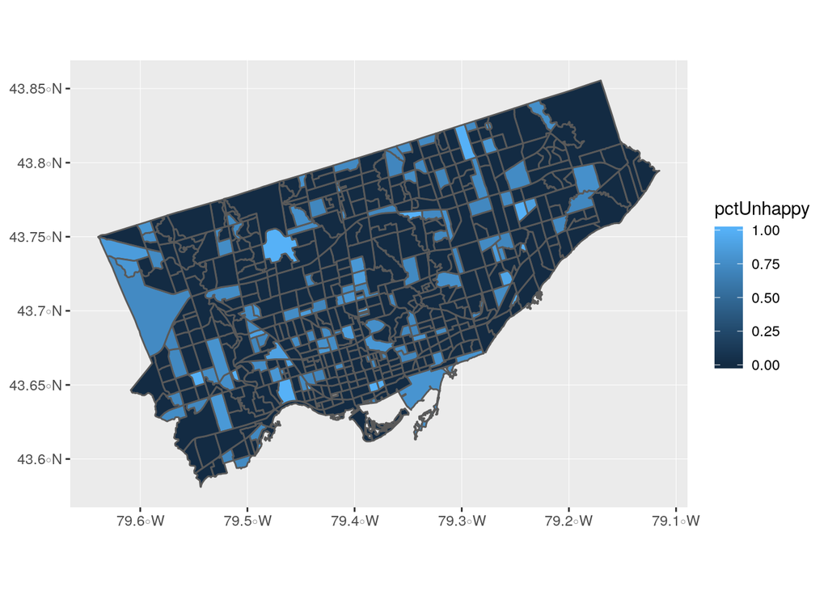

```r
displayPctUnhappy(mytoronto,s)
```

```r
s <-  simulate(1000,s, tolerance)
```

```
## step :  200
## step :  400
## step :  600
## step :  800
## step :  1000
```

```r
nrow(getUnhappy(s))
```

```
## [1] 8187
```

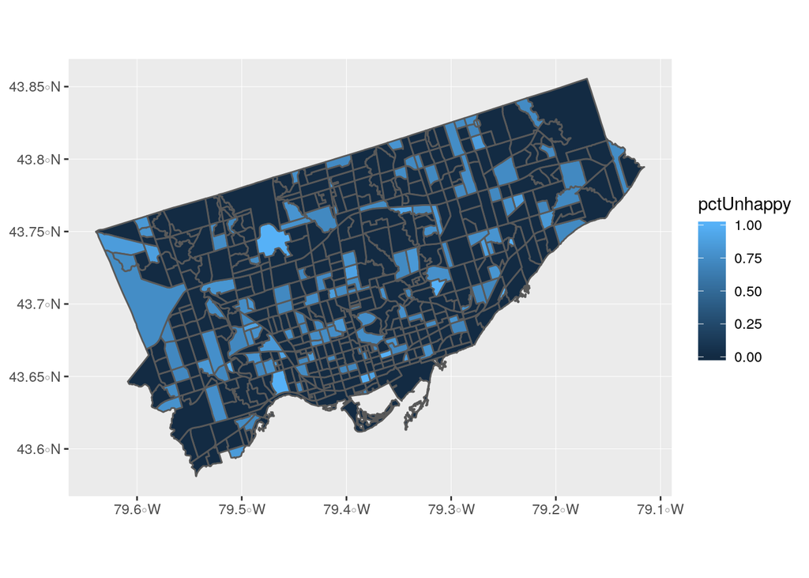

```r
displayPctUnhappy(mytoronto,s)
```

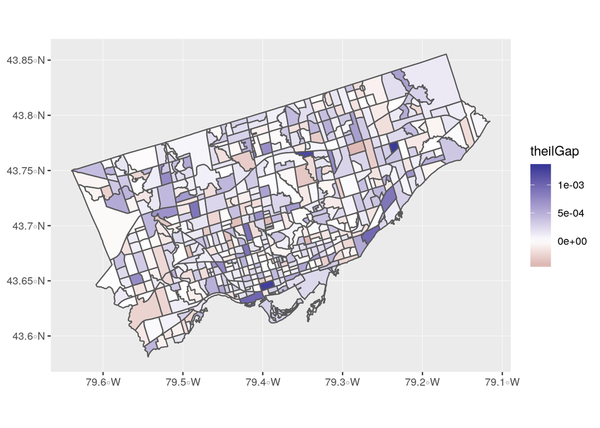

```r
displayTheilGap(mytoronto,s)
```

## Taking vacancy into account

For now , vacancy of tracts was not taken into account. We have to create new columns to keep track of empty households in toronto, and simulated population in each tract.

```r
mytoronto$popSchelling <-  NA
vacancypct <-0.03
mytoronto$emptyHouseholds <-   round(vacancypct   * mytoronto$Households)
```

We now have to update the `moveOne` function to update the emptyhouseholds when someone moves.

```r
moveOne <-  function(state, tolerance, mytoronto){
  if (nrow(getUnhappy(state))==0){
    cat("evryone happy \n")
    return(state)
  }

  #take one unhappy householder
  unhappyHHs <-  getUnhappy(state)
  uhhhID <- sample(unhappyHHs$ID, 1)

  #take one tract with free space
  tractIDSfree <-  mytoronto[mytoronto$emptyHouseholds >0,"GeoUID" ]
  destiTract <-  sample(tractIDSfree$GeoUID, 1)

  origTract <-  state[uhhhID,"localisation"]

  #the localisation of the housholder change
  state[uhhhID,"localisation"] <-  destiTract

  #number of empty housholds have to be updated
  mytoronto[mytoronto$GeoUID==destiTract,]$emptyHouseholds <-    mytoronto[mytoronto$GeoUID==destiTract,]$emptyHouseholds -1
  mytoronto[mytoronto$GeoUID==origTract,]$emptyHouseholds <-  mytoronto[mytoronto$GeoUID==origTract,]$emptyHouseholds +1


  #happiness update in concerned tracts
  state <-  updateHappinessOftract(origTract,state, tolerance )
  state <-  updateHappinessOftract(destiTract,state, tolerance )


  return(state)
}
```

The `simulate` function has also to be updated, since it calls `moveOne`. Therer is a lot of commented code , that is prepared for logging measures over time. We will add accumulators if we have time !

```r
simulate <-  function(steps, state, tolerance, mytoronto, logMeasures=F){
  for (i in 1:steps){
    if (i %% 200 ==0) {
      cat("step : ", i , "\n")
      cat(nrow(getUnhappy(state)), "unhappy housholders \n")
    }

    if (nrow(getUnhappy(state)) == 0){
      cat("Everybody is fine with their location\n")
      break
    }
    state <- moveOne(state,tolerance,mytoronto)
    # if (logMeasures){
    #
    #   mytoronto$theil <-  sapply(tractIDS, FUN = theilEntropyBytract, state )
    #   theilE <- theilEntropy(state)
    #   mytoronto$theilGap <- theilE - mytoronto$theil
    #   #notice the tricky super affectation <<- to acces global variable outside the scope of the function
    #   stepsACC <<-  append(stepsACC, i)
    #   NbunhappyAcc <<-  append( NbunhappyAcc, nrow(getUnhappy(state)))
    #   absTheilGapSumAcc <<-  append(absTheilGapSumAcc, sum(abs(mytoronto$theilGap),na.rm = T))
    # }


      }
  return(state)
}
```

## Final workflow

We gather everything to setup a state and launch a simulation

```r
nbgroups <-  4
groupValues <-  seq.int(from = 1, to=nbgroups)
colorMapping <-  brewer.pal(nbgroups,"Dark2")
pctList <- c(0.6, 0.1, 0.1, 0.2)
tolerance <-  0.3

s <-  setupState(10000, mytoronto,pctList,groupValues, tolerance)
mytoronto <-  updateMeasuresToronto(mytoronto,s)
nrow(getUnhappy(s))
```

```
## [1] 8563
```

```r
sum(mytoronto$emptyHouseholds)
```

```
## [1] 33392
```

```r
s <-  simulate(1000,s, tolerance, mytoronto)
```

```
## step :  200
## 8389 unhappy housholders
## step :  400
## 8318 unhappy housholders
## step :  600
## 8286 unhappy housholders
## step :  800
## 8306 unhappy housholders
## step :  1000
## 8259 unhappy housholders
```

```r
nrow(getUnhappy(s))
```

```
## [1] 8259
```

```r
sum(mytoronto$emptyHouseholds)
```

```
## [1] 33392
```

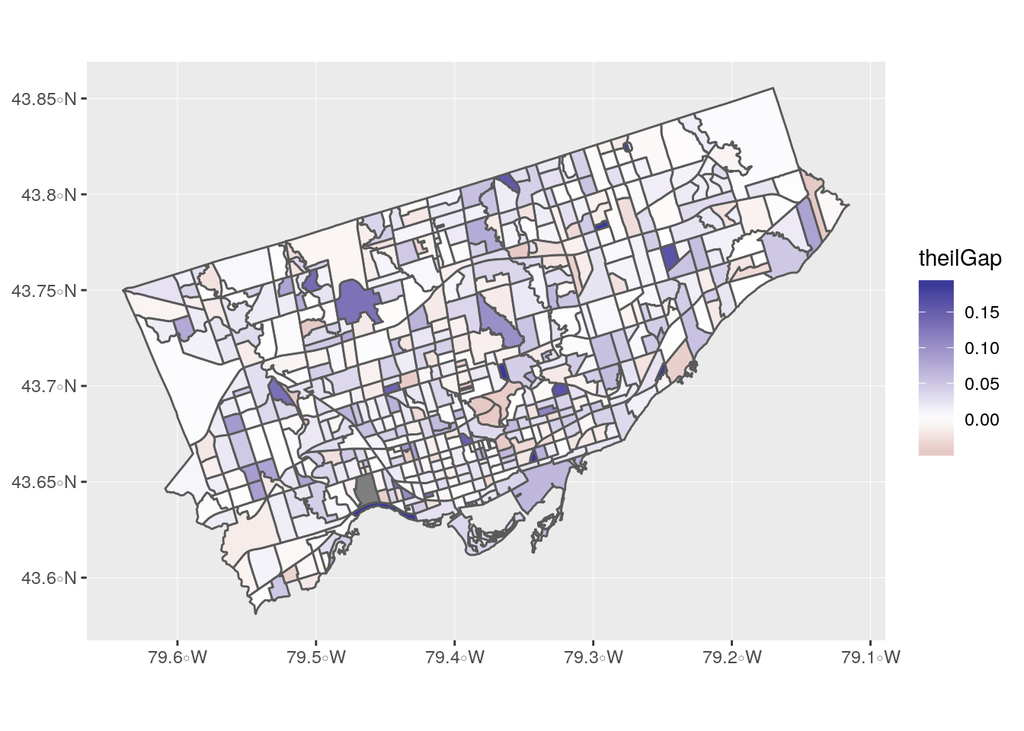

```r
displayTheilGap(mytoronto,s)
```

You can notice that the number of emptyhousholders remains constant (that’s good) and the number of unhappy householders can decrease but also increase sometimes (that’s normal : when someone turn unhappy in a tract, every person of the same group turns unhappy too! ).